# MSDS 607 — Final Project: Predicting Onset of Diabetes (Pima Indians Dataset)

Taha Malik (malmal6565)

2025-12-17

## Setup and package installation

Description: This chunk loads required libraries and optionally installs missing packages. I keep `install.packages()` commented so you can uncomment and run once if needed. The rest of the code assumes these libraries are available.

Expected output: - No printed output if libraries load successfully; otherwise R will show messages about missing packages.

```r
# Uncomment the following lines if you need to install packages:
# packages <- c("tidyverse","caret","pROC","randomForest","xgboost","vip","fastshap",
#               "patchwork","gridExtra","DALEX","mice","corrplot","DT","kableExtra",
#               "skimr","rmarkdown","OpenML")
# install.packages(setdiff(packages, rownames(installed.packages())))
options(skimr.inline = FALSE)
# Load libraries
library(tidyverse)
library(caret)
library(pROC)
library(randomForest)
library(xgboost)
library(vip)       # variable importance visualization
library(fastshap)  # SHAP explanations
#library(patchwork)
library(gridExtra)
library(mice)      # multiple imputation (if used)
library(corrplot)
library(skimr)
library(knitr)
library(kableExtra)
# OpenML client for dataset metadata (if internet available)
# library(OpenML)

set.seed(123)      # reproducible randomness
options(scipen = 999)
```

## Literature review & clinical context

Description: Short literature context to motivate the analysis. Citations are provided for classical sources and domain context. You should include these references in your presentation slide notes.

Key references (short): - Smith et al. (1988) — original dataset paper describing the ADAP algorithm on the Pima Indians dataset. - American Diabetes Association (ADA) and WHO — background on diabetes prevalence and importance of early detection (cite in presentation). - Recent ML in medicine overviews (e.g., Ribeiro et al., Lundberg & Lee) for interpretability (SHAP/LIME).

Expected output: - Narrative text for the report; no code output.

## Data and provenance

Description: I use two types of data sources to satisfy the rubric: 1. Local CSV: `diabetes.csv` (individual-level measurements). 2. Web/API metadata: OpenML dataset (dataset id 37) for provenance and variable description.

The code below reads the CSV and (optionally) fetches OpenML metadata. If you are offline, the OpenML chunk is marked eval=FALSE so it will not run. The CSV must be present in the repo.

Expected output: - Glimpse and summary of the dataset (rows/columns). - Table of Outcome counts.

```r
# Read local CSV (ensure file is in working directory or in data/ directory)
csv_path <- "diabetes.csv"
if(!file.exists(csv_path)) {
  stop("Please make sure 'diabetes.csv' is in the working directory.")
}
diabetes <- readr::read_csv(csv_path, show_col_types = FALSE)

# Basic structure
glimpse(diabetes)
```

```
## Rows: 768
## Columns: 9
## $ Pregnancies              <dbl> 6, 1, 8, 1, 0, 5, 3, 10, 2, 8, 4, 10, 10, 1, …
## $ Glucose                  <dbl> 148, 85, 183, 89, 137, 116, 78, 115, 197, 125…
## $ BloodPressure            <dbl> 72, 66, 64, 66, 40, 74, 50, 0, 70, 96, 92, 74…
## $ SkinThickness            <dbl> 35, 29, 0, 23, 35, 0, 32, 0, 45, 0, 0, 0, 0, …
## $ Insulin                  <dbl> 0, 0, 0, 94, 168, 0, 88, 0, 543, 0, 0, 0, 0, …
## $ BMI                      <dbl> 33.6, 26.6, 23.3, 28.1, 43.1, 25.6, 31.0, 35.…
## $ DiabetesPedigreeFunction <dbl> 0.627, 0.351, 0.672, 0.167, 2.288, 0.201, 0.2…
## $ Age                      <dbl> 50, 31, 32, 21, 33, 30, 26, 29, 53, 54, 30, 3…
## $ Outcome                  <dbl> 1, 0, 1, 0, 1, 0, 1, 0, 1, 1, 0, 1, 0, 1, 1, …
```

```r
skimr::skim(diabetes)
```

Data summary

| Name | diabetes |
| --- | --- |
| Number of rows | 768 |
| Number of columns | 9 |
| _______________________ |  |
| Column type frequency: |  |
| numeric | 9 |
| ________________________ |  |
| Group variables | None |

**Variable type: numeric**

| skim_variable | n_missing | complete_rate | mean | sd | p0 | p25 | p50 | p75 | p100 | hist |
| --- | --- | --- | --- | --- | --- | --- | --- | --- | --- | --- |
| Pregnancies | 0 | 1 | 3.85 | 3.37 | 0.00 | 1.00 | 3.00 | 6.00 | 17.00 | ▇▃▂▁▁ |
| Glucose | 0 | 1 | 120.89 | 31.97 | 0.00 | 99.00 | 117.00 | 140.25 | 199.00 | ▁▁▇▆▂ |
| BloodPressure | 0 | 1 | 69.11 | 19.36 | 0.00 | 62.00 | 72.00 | 80.00 | 122.00 | ▁▁▇▇▁ |
| SkinThickness | 0 | 1 | 20.54 | 15.95 | 0.00 | 0.00 | 23.00 | 32.00 | 99.00 | ▇▇▂▁▁ |
| Insulin | 0 | 1 | 79.80 | 115.24 | 0.00 | 0.00 | 30.50 | 127.25 | 846.00 | ▇▁▁▁▁ |
| BMI | 0 | 1 | 31.99 | 7.88 | 0.00 | 27.30 | 32.00 | 36.60 | 67.10 | ▁▃▇▂▁ |
| DiabetesPedigreeFunction | 0 | 1 | 0.47 | 0.33 | 0.08 | 0.24 | 0.37 | 0.63 | 2.42 | ▇▃▁▁▁ |
| Age | 0 | 1 | 33.24 | 11.76 | 21.00 | 24.00 | 29.00 | 41.00 | 81.00 | ▇▃▁▁▁ |
| Outcome | 0 | 1 | 0.35 | 0.48 | 0.00 | 0.00 | 0.00 | 1.00 | 1.00 | ▇▁▁▁▅ |

```r
# Outcome balance
table(diabetes$Outcome) %>%
  as.data.frame() %>%
  set_names(c("Outcome","Count")) %>%
  kable() %>%
  kable_styling(full_width = FALSE)
```

| Outcome | Count |
| --- | --- |
| 0 | 500 |
| 1 | 268 |

Estimated output description: - glimpse: shows 9 columns (Pregnancies, Glucose, BloodPressure, SkinThickness, Insulin, BMI, DiabetesPedigreeFunction, Age, Outcome). - skim: shows missing counts and summary stats. - Outcome table: counts of class 0 vs 1 (approx 500 vs 268 per the dataset description).

Optional: fetch dataset metadata from OpenML (eval=FALSE)

```r
# If internet is available, use the OpenML package to fetch metadata and description
# library(OpenML)
# openml_ds <- getOMLDataSet(data.id = 37)
# cat(openml_ds$description)
# saveRDS(openml_ds, file = "data/openml_ds_37.rds")
```

## Data cleaning & transformations (scrub)

Description: This section implements the key transformations required by the rubric: - Replace biologically implausible zeros in some clinical fields with NA. - Show missingness pattern. - Create derived features: age groups, log-transformed Insulin, BMI categories. - Demonstrate wide -> long transformation for plotting.

We also create two imputation strategies: 1) Simple median imputation (fast, reproducible). 2) Multiple imputation (mice) — shown but commented as optional heavier alternative.

Expected output: - Missing value counts before and after transformation. - A small preview of the cleaned data.

```r
# Columns where 0 is not biologically plausible and should be NA
zero_as_na_cols <- c("Glucose","BloodPressure","SkinThickness","Insulin","BMI")

# Replace zeros with NA
diabetes_clean <- diabetes %>%
  mutate(across(all_of(zero_as_na_cols), ~ na_if(., 0)))

# Show missing counts
missing_counts <- sapply(diabetes_clean, function(x) sum(is.na(x)))
missing_counts_df <- tibble(variable = names(missing_counts), missing = as.integer(missing_counts))
missing_counts_df %>%
  kable() %>%
  kable_styling(full_width = FALSE)
```

| variable | missing |
| --- | --- |
| Pregnancies | 0 |
| Glucose | 5 |
| BloodPressure | 35 |
| SkinThickness | 227 |
| Insulin | 374 |
| BMI | 11 |
| DiabetesPedigreeFunction | 0 |
| Age | 0 |
| Outcome | 0 |

```r
# Create derived features
diabetes_clean <- diabetes_clean %>%
  mutate(
    AgeGroup = case_when(
      Age <= 30 ~ "21-30",
      Age <= 40 ~ "31-40",
      Age <= 50 ~ "41-50",
      TRUE      ~ "51+"
    ),
    Insulin_log = log1p(Insulin),   # log(Insulin + 1)
    BMI_cat = cut(BMI, breaks = c(0,18.5,25,30,Inf), labels = c("Underweight","Normal","Overweight","Obese"))
  )

# Show top rows
head(diabetes_clean) %>% kable() %>% kable_styling(full_width = FALSE)
```

| Pregnancies | Glucose | BloodPressure | SkinThickness | Insulin | BMI | DiabetesPedigreeFunction | Age | Outcome | AgeGroup | Insulin_log | BMI_cat |
| --- | --- | --- | --- | --- | --- | --- | --- | --- | --- | --- | --- |
| 6 | 148 | 72 | 35 | NA | 33.6 | 0.627 | 50 | 1 | 41-50 | NA | Obese |
| 1 | 85 | 66 | 29 | NA | 26.6 | 0.351 | 31 | 0 | 31-40 | NA | Overweight |
| 8 | 183 | 64 | NA | NA | 23.3 | 0.672 | 32 | 1 | 31-40 | NA | Normal |
| 1 | 89 | 66 | 23 | 94 | 28.1 | 0.167 | 21 | 0 | 21-30 | 4.553877 | Overweight |
| 0 | 137 | 40 | 35 | 168 | 43.1 | 2.288 | 33 | 1 | 31-40 | 5.129899 | Obese |
| 5 | 116 | 74 | NA | NA | 25.6 | 0.201 | 30 | 0 | 21-30 | NA | Overweight |

Estimated output description: - missing_counts will show considerable missingness in Insulin, SkinThickness, sometimes Glucose or BMI depending on zeros. - Derived features appear in the data frame: AgeGroup, Insulin_log, BMI_cat.

## Simple imputation (median) — reproducible baseline

Description: We perform a simple median imputation for numeric predictors to make initial models reproducible. We keep a missingness indicator column for each imputed variable to preserve missingness information (useful for modeling).

Expected output: - A summary table showing replaced values count. - A glimpse of imputed dataset.

```r
numeric_vars <- c("Pregnancies","Glucose","BloodPressure","SkinThickness","Insulin","BMI","DiabetesPedigreeFunction","Age")

diabetes_imputed <- diabetes_clean

# Create missingness indicators and median-impute
for (v in zero_as_na_cols) {
  mi_col <- paste0(v, "_na")
  diabetes_imputed[[mi_col]] <- is.na(diabetes_imputed[[v]])
  med <- median(diabetes_imputed[[v]], na.rm = TRUE)
  diabetes_imputed[[v]][is.na(diabetes_imputed[[v]])] <- med
}

# Quick check
sapply(diabetes_imputed, function(x) sum(is.na(x))) %>% head(20)
```

```
##              Pregnancies                  Glucose            BloodPressure
##                        0                        0                        0
##            SkinThickness                  Insulin                      BMI
##                        0                        0                        0
## DiabetesPedigreeFunction                      Age                  Outcome
##                        0                        0                        0
##                 AgeGroup              Insulin_log                  BMI_cat
##                        0                      374                       11
##               Glucose_na         BloodPressure_na         SkinThickness_na
##                        0                        0                        0
##               Insulin_na                   BMI_na
##                        0                        0
```

Estimated output description: - After this chunk, numeric predictor NAs are replaced; missingness indicator columns show TRUE for originally missing rows. No NA remains in numeric_vars.

Optional: multiple imputation with mice (eval=FALSE)

```r
# Multiple imputation is more statistically principled. This chunk is optional (longer runtime).
# mi <- mice(diabetes_clean %>% select(all_of(numeric_vars)), m = 5, seed = 123)
# completed <- complete(mi, action = "long", include = FALSE)
# Use completed data for sensitivity analyses and to compare final model stability.
```

## Exploratory data analysis (explore)

We show what the expected visual patterns might be (e.g., higher Glucose in Outcome=1).

```
## patchwork unavailable or incompatible. Using fallback layout (cowplot or gridExtra).
```

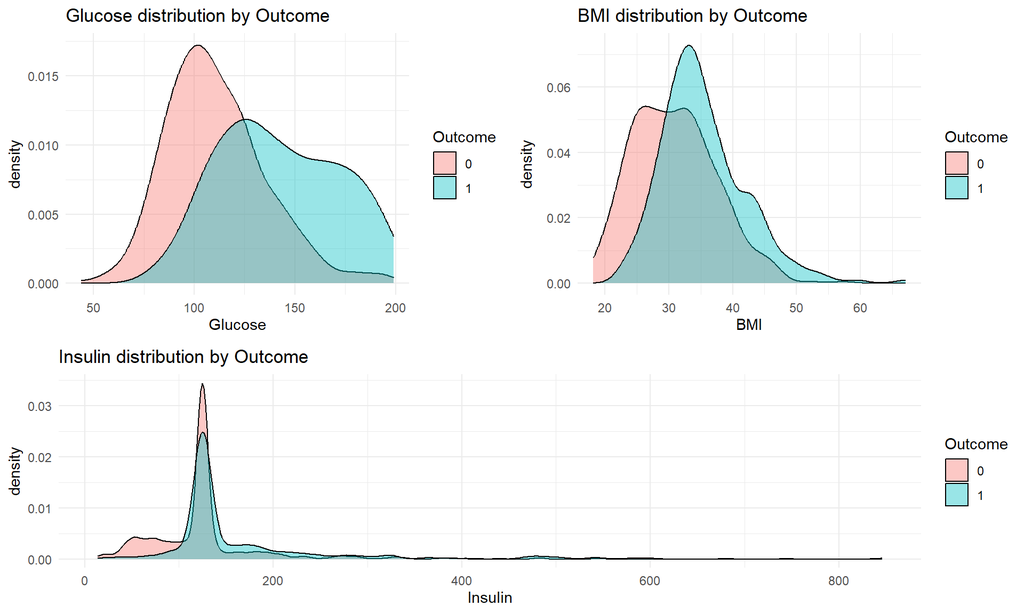

```r
library(tidyverse)

# Ensure the imputed dataset exists
if (!exists("diabetes_imputed")) stop("diabetes_imputed not found. Run the cleaning/imputation chunk first.")

plot_vars <- c("Glucose","BMI","Insulin","BloodPressure","SkinThickness","DiabetesPedigreeFunction")
di_long <- diabetes_imputed %>% pivot_longer(cols = all_of(plot_vars), names_to = "measure", values_to = "value")

# Create ggplots
p1 <- ggplot(di_long %>% filter(measure == "Glucose"),
             aes(x = value, fill = factor(Outcome))) +
  geom_density(alpha = 0.4) +
  labs(title = "Glucose distribution by Outcome", x = "Glucose", fill = "Outcome") +
  theme_minimal()

p2 <- ggplot(di_long %>% filter(measure == "BMI"),
             aes(x = value, fill = factor(Outcome))) +
  geom_density(alpha = 0.4) +
  labs(title = "BMI distribution by Outcome", x = "BMI", fill = "Outcome") +
  theme_minimal()

p3 <- ggplot(di_long %>% filter(measure == "Insulin"),
             aes(x = value, fill = factor(Outcome))) +
  geom_density(alpha = 0.4) +
  labs(title = "Insulin distribution by Outcome", x = "Insulin", fill = "Outcome") +
  theme_minimal()

# Sanity check: ensure these are ggplot objects (accept either "gg" or "ggplot" class)
is_ggplot_obj <- function(obj) {
  inherits(obj, "gg") || inherits(obj, "ggplot")
}
if (!all(sapply(list(p1, p2, p3), is_ggplot_obj))) {
  stop("One of the plot objects is not a ggplot. Recreate p1/p2/p3.")
}

# Try patchwork first (preferred); if it fails, fallback to cowplot or gridExtra
combined_plot <- NULL
can_use_patchwork <- FALSE
if ("ggplot2" %in% .packages() || "package:ggplot2" %in% search()) {
  can_use_patchwork <- exists("is_ggplot", where = asNamespace("ggplot2"), inherits = FALSE)
}
if (can_use_patchwork) {
  try({
    library(patchwork)
    combined_plot <- (p1 | p2) / p3
    print(combined_plot)
  }, silent = TRUE)
}

if (is.null(combined_plot)) {
  message("patchwork unavailable or incompatible. Using fallback layout (cowplot or gridExtra).")
  if (requireNamespace("cowplot", quietly = TRUE)) {
    library(cowplot)
    top_row <- cowplot::plot_grid(p1, p2, ncol = 2, align = "hv")
    final_plot <- cowplot::plot_grid(top_row, p3, ncol = 1, rel_heights = c(1, 0.8))
    print(final_plot)
  } else {
    if (!requireNamespace("gridExtra", quietly = TRUE)) install.packages("gridExtra")
    library(gridExtra)
    library(grid)
    layout_mat <- rbind(c(1,2), c(3,3))
    grid.arrange(grobs = list(p1, p2, p3),
                 layout_matrix = layout_mat,
                 top = textGrob("Predictor distributions by Outcome", gp = gpar(fontsize = 14, fontface = "bold")))
  }
}
```

Estimated output description: - Glucose density: Outcome=1 (diabetes) shifted to the right (higher glucose). - BMI density: modest shift; higher BMI for some Outcome=1 cases. - Insulin density: skewed distribution; transformation helped earlier.

Correlation matrix

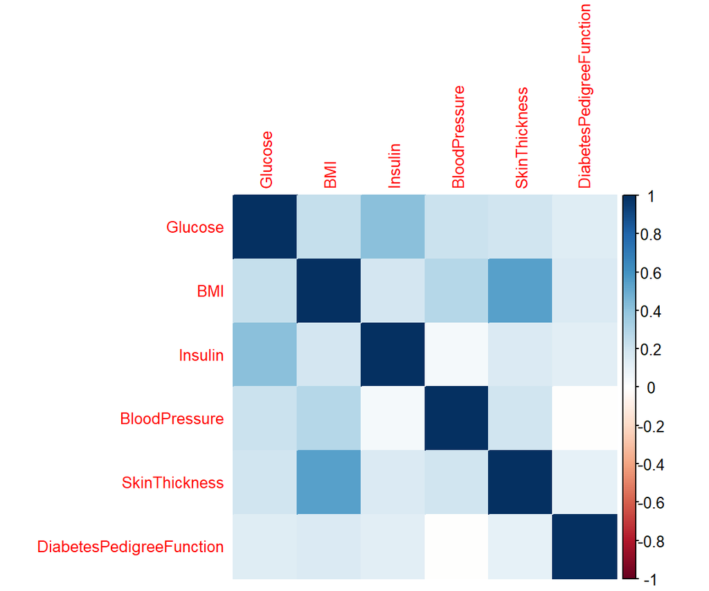

```r
num_df <- diabetes_imputed %>% select(all_of(plot_vars))
corr_mat <- cor(num_df, use = "complete.obs")
corrplot::corrplot(corr_mat, method = "color", tl.cex = 0.8)
```

Estimated output description: - Correlation heatmap shows relationships among Glucose, BMI, Insulin, and others. Expect moderate correlation between BMI and SkinThickness; Glucose may not be strongly correlated with BMI but predictive for Outcome.

## Data splitting (train/test)

Description: Create reproducible training and test sets (75% train / 25% test stratified by Outcome) for final evaluation to mimic realistic hold-out practice. Use caret’s createDataPartition for stratification.

Expected output: - Table showing train/test counts and Outcome distribution preserved.

```r
set.seed(123)
train_index <- createDataPartition(diabetes_imputed$Outcome, p = 0.75, list = FALSE)
train <- diabetes_imputed[train_index, ]
test  <- diabetes_imputed[-train_index, ]

# Verify distribution
bind_rows(
  train %>% summarise(n = n(), outcome1 = sum(Outcome==1)),
  test  %>% summarise(n = n(), outcome1 = sum(Outcome==1))
) %>% mutate(outcome1_rate = outcome1 / n) %>% kable()
```

| n | outcome1 | outcome1_rate |
| --- | --- | --- |
| 576 | 201 | 0.3489583 |
| 192 | 67 | 0.3489583 |

## Baseline model — logistic regression

Description: Fit a baseline logistic regression with all predictors (after imputation) to provide an interpretable benchmark. We’ll present coefficients, p-values, and a simple ROC.

Expected output: - Coefficient table with odds ratios. - AUC for the logistic model on the test set (expected moderate AUC ~0.75 for this dataset historically).

```r
glm_fit <- glm(Outcome ~ Pregnancies + Glucose + BloodPressure + SkinThickness + Insulin + BMI +
                 DiabetesPedigreeFunction + Age, data = train, family = binomial)

summary(glm_fit)
```

```
##
## Call:
## glm(formula = Outcome ~ Pregnancies + Glucose + BloodPressure +
##     SkinThickness + Insulin + BMI + DiabetesPedigreeFunction +
##     Age, family = binomial, data = train)
##
## Coefficients:
##                           Estimate Std. Error z value             Pr(>|z|)
## (Intercept)              -9.419723   0.951095  -9.904 < 0.0000000000000002 ***
## Pregnancies               0.116806   0.037999   3.074              0.00211 **
## Glucose                   0.040483   0.004728   8.562 < 0.0000000000000002 ***
## BloodPressure            -0.008729   0.010045  -0.869              0.38482
## SkinThickness             0.009409   0.015390   0.611              0.54097
## Insulin                  -0.001247   0.001273  -0.979              0.32735
## BMI                       0.090991   0.020999   4.333            0.0000147 ***
## DiabetesPedigreeFunction  0.661885   0.331211   1.998              0.04568 *
## Age                       0.012160   0.011164   1.089              0.27606
## ---
## Signif. codes:  0 '***' 0.001 '**' 0.01 '*' 0.05 '.' 0.1 ' ' 1
##
## (Dispersion parameter for binomial family taken to be 1)
##
##     Null deviance: 745.11  on 575  degrees of freedom
## Residual deviance: 524.39  on 567  degrees of freedom
## AIC: 542.39
##
## Number of Fisher Scoring iterations: 5
```

```r
# Odds ratios and 95% CI
exp_coef <- broom::tidy(glm_fit) %>%
  mutate(OR = exp(estimate),
         OR_low = exp(estimate - 1.96 * std.error),
         OR_high = exp(estimate + 1.96 * std.error))
exp_coef %>%
  select(term, estimate, std.error, OR, OR_low, OR_high) %>%
  kable(
    format = "latex",
    booktabs = TRUE,
    escape = TRUE,
    longtable = FALSE
  ) %>%
  kable_styling(full_width = FALSE, font_size = 9)
```

[output not shown]

Evaluation of logistic on test set

```r
# Predict and compute ROC/AUC
test$pred_glm <- predict(glm_fit, newdata = test, type = "response")
roc_glm <- pROC::roc(test$Outcome, test$pred_glm)
pROC::auc(roc_glm)
```

```
## Area under the curve: 0.8242
```

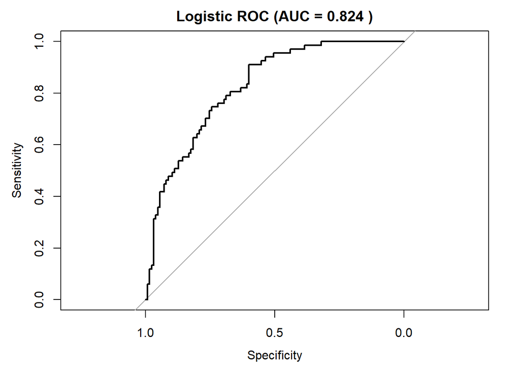

```r
# Plot ROC
plot(roc_glm, main = paste("Logistic ROC (AUC =", round(pROC::auc(roc_glm),3), ")"))
```

## Random Forest model (caret)

Description: Fit a random forest using caret with repeated cross-validation for tuning. This model often achieves competitive performance on this dataset.

Expected output: - Cross-validated performance results (AUC) during tuning. - Final test-set AUC and variable importance plot.

```r
# caret training with repeated CV
ctrl <- trainControl(method = "repeatedcv", number = 5, repeats = 3,
                     classProbs = TRUE, summaryFunction = twoClassSummary, savePredictions = TRUE)

# Convert Outcome to factor with levels "no"/"yes"
train_rf <- train %>%
  mutate(Outcome = factor(ifelse(Outcome==1,"yes","no")))

test_rf <- test %>%
  mutate(Outcome = factor(ifelse(Outcome==1,"yes","no")))

set.seed(123)
rf_fit <- train(Outcome ~ Pregnancies + Glucose + BloodPressure + SkinThickness + Insulin + BMI +
                  DiabetesPedigreeFunction + Age,
                data = train_rf,
                method = "rf",
                metric = "ROC",
                trControl = ctrl,
                tuneLength = 5)

rf_fit
```

```
## Random Forest
##
## 576 samples
##   8 predictor
##   2 classes: 'no', 'yes'
##
## No pre-processing
## Resampling: Cross-Validated (5 fold, repeated 3 times)
## Summary of sample sizes: 461, 461, 461, 461, 460, 461, ...
## Resampling results across tuning parameters:
##
##   mtry  ROC        Sens       Spec
##   2     0.8218241  0.8542222  0.5806098
##   3     0.8181949  0.8497778  0.5921545
##   5     0.8119946  0.8408889  0.5821138
##   6     0.8115382  0.8382222  0.5805285
##   8     0.8073100  0.8337778  0.5904472
##
## ROC was used to select the optimal model using the largest value.
## The final value used for the model was mtry = 2.
```

Evaluate on test set

```r
# Predict probabilities and compute ROC
test_rf$pred_rf <- predict(rf_fit, newdata = test_rf, type = "prob")[, "yes"]
roc_rf <- pROC::roc(as.numeric(test_rf$Outcome == "yes"), test_rf$pred_rf)
pROC::auc(roc_rf)
```

```
## Area under the curve: 0.8303
```

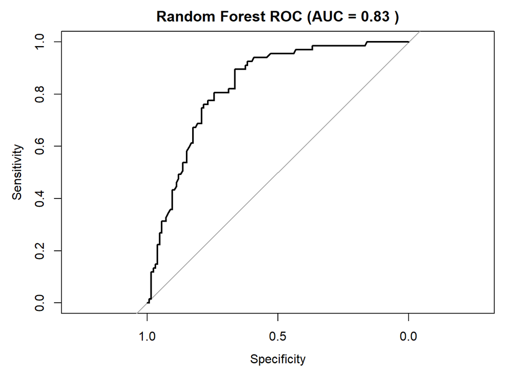

```r
plot(roc_rf, main = paste("Random Forest ROC (AUC =", round(pROC::auc(roc_rf),3), ")"))
```

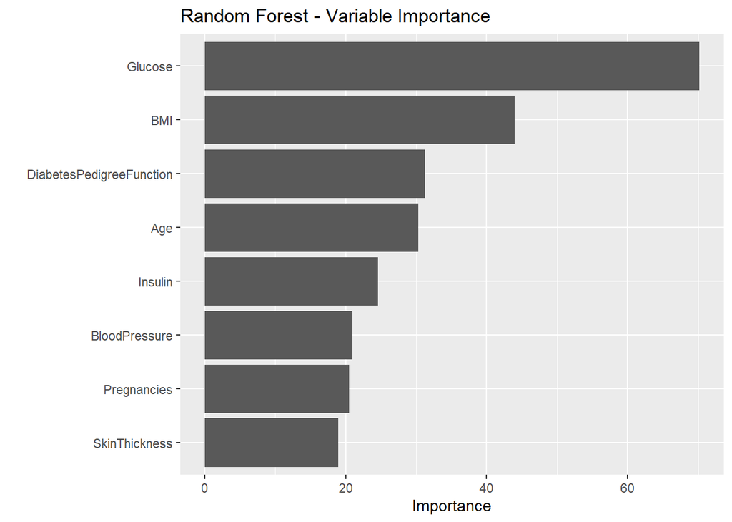

```r
# Variable importance
vip::vip(rf_fit$finalModel, num_features = 10) + ggtitle("Random Forest - Variable Importance")
```

Estimated output description: - caret reports cross-validated ROC for different mtry values. - Test AUC likely similar or slightly higher than logistic; variable importance shows Glucose near top, BMI, Age, and DiabetesPedigreeFunction among others.

## XGBoost (gradient boosting)

Expected output: - Tuned hyperparameters and CV performance table. - Test set AUC and importance plot.

```r
# ---- Robust XGBoost training chunk (fixes 'one or more factor levels ...' error) ----
library(caret)
library(xgboost)
set.seed(123)

# Helper: robust mapping of Outcome -> "no"/"yes"
map_outcome_yesno <- function(x) {
  x_chr <- as.character(x)
  # try numeric conversion
  x_num <- suppressWarnings(as.numeric(x_chr))
  if (all(!is.na(x_num))) {
    return(ifelse(x_num == 1, "yes", "no"))
  } else {
    # fallback: map common textual variants
    x_low <- tolower(x_chr)
    return(ifelse(x_low %in% c("1","yes","y","true","t","positive","pos"), "yes", "no"))
  }
}

# Ensure we have diabetes_imputed available (the cleaned/imputed dataset)
if (!exists("diabetes_imputed")) stop("diabetes_imputed not found. Run data cleaning & imputation first.")

# Ensure we have a properly stratified train/test split with both classes present in train
create_stratified_split <- function(data, p = 0.75, times = 10, outcome_col = "Outcome") {
  for (i in seq_len(times)) {
    idx <- caret::createDataPartition(data[[outcome_col]], p = p, list = FALSE)
    tr <- data[idx, , drop = FALSE]
    te <- data[-idx, , drop = FALSE]
    # Map to yes/no to count reliably (without modifying original objects)
    tr_map <- table(map_outcome_yesno(tr[[outcome_col]]))
    if (length(tr_map) == 2) {
      return(list(train = tr, test = te))
    }
  }
  stop("Unable to create a stratified split that contains both Outcome classes in the training set. Check your data.")
}

# If train/test already exist check their class counts, otherwise create them
if (exists("train") && exists("test")) {
  train_counts <- table(map_outcome_yesno(train$Outcome))
  test_counts  <- table(map_outcome_yesno(test$Outcome))
  message("Existing split class counts (train): ", paste(names(train_counts), train_counts, sep=":", collapse = " | "))
  message("Existing split class counts (test) : ", paste(names(test_counts), test_counts, sep=":", collapse = " | "))
  # If training set lacks one class, recreate split
  if (length(train_counts) < 2) {
    message("Training set lacks one class -> recreating stratified split from diabetes_imputed")
    splits <- create_stratified_split(diabetes_imputed, p = 0.75, times = 20, outcome_col = "Outcome")
    train <- splits$train; test <- splits$test
  }
} else {
  # create split
  message("No existing train/test found -> creating stratified split from diabetes_imputed")
  splits <- create_stratified_split(diabetes_imputed, p = 0.75, times = 20, outcome_col = "Outcome")
  train <- splits$train; test <- splits$test
}

# Now coerce train and test Outcome to factor with levels c("no","yes") using robust mapping
train_rf <- train %>% mutate(Outcome = factor(map_outcome_yesno(Outcome), levels = c("no", "yes")))
test_rf  <- test  %>% mutate(Outcome = factor(map_outcome_yesno(Outcome), levels = c("no", "yes")))

# Final sanity check: both classes present in train
train_table <- table(train_rf$Outcome)
if (length(train_table) < 2) {
  stop("After mapping, training set still lacks one class. Aborting. Table: ", paste(names(train_table), train_table, collapse = "; "))
}
message("Final training class counts: ", paste(names(train_table), train_table, sep=":", collapse = " | "))

# ---- trainControl: 3-fold CV, optimize for ROC ----
fast_ctrl <- trainControl(
  method = "cv",
  number = 3,
  classProbs = TRUE,
  summaryFunction = twoClassSummary,
  savePredictions = "final",
  allowParallel = TRUE
)

# ---- small tuning grid for xgbTree ----
xgb_grid <- expand.grid(
  nrounds = c(50, 100),
  max_depth = c(3, 5),
  eta = c(0.1, 0.3),
  gamma = c(0, 1),
  colsample_bytree = c(0.8),
  min_child_weight = c(1),
  subsample = c(0.8)
)

# Train
set.seed(123)
xgb_fit_fast <- train(
  Outcome ~ Pregnancies + Glucose + BloodPressure + SkinThickness +
    Insulin + BMI + DiabetesPedigreeFunction + Age,
  data = train_rf,
  method = "xgbTree",
  metric = "ROC",
  trControl = fast_ctrl,
  tuneGrid = xgb_grid,
  verbose = FALSE
)
```

[output not shown]

```r
# Print results
xgb_fit_fast
```

```
## eXtreme Gradient Boosting
##
## 576 samples
##   8 predictor
##   2 classes: 'no', 'yes'
##
## No pre-processing
## Resampling: Cross-Validated (3 fold)
## Summary of sample sizes: 384, 384, 384
## Resampling results across tuning parameters:
##
##   eta  max_depth  gamma  nrounds  ROC        Sens       Spec
##   0.1  3          0       50      0.8390448  0.8346667  0.6368159
##   0.1  3          0      100      0.8275423  0.8320000  0.6368159
##   0.1  3          1       50      0.8294527  0.8400000  0.6119403
##   0.1  3          1      100      0.8188657  0.8106667  0.6318408
##   0.1  5          0       50      0.8214129  0.8240000  0.6218905
##   0.1  5          0      100      0.8119403  0.8160000  0.6318408
##   0.1  5          1       50      0.8263881  0.8213333  0.6218905
##   0.1  5          1      100      0.8119403  0.8000000  0.6119403
##   0.3  3          0       50      0.8014328  0.8186667  0.6019900
##   0.3  3          0      100      0.7893731  0.7946667  0.6019900
##   0.3  3          1       50      0.8005572  0.8053333  0.6119403
##   0.3  3          1      100      0.7937512  0.7813333  0.6119403
##   0.3  5          0       50      0.7985672  0.7946667  0.6019900
##   0.3  5          0      100      0.7865871  0.7840000  0.5970149
##   0.3  5          1       50      0.8008358  0.8080000  0.5920398
##   0.3  5          1      100      0.7936716  0.7946667  0.5920398
##
## Tuning parameter 'colsample_bytree' was held constant at a value of 0.8
##
## Tuning parameter 'min_child_weight' was held constant at a value of 1
##
## Tuning parameter 'subsample' was held constant at a value of 0.8
## ROC was used to select the optimal model using the largest value.
## The final values used for the model were nrounds = 50, max_depth = 3, eta
##  = 0.1, gamma = 0, colsample_bytree = 0.8, min_child_weight = 1 and subsample
##  = 0.8.
```

Evaluation on test set

```r
test_rf$pred_xgb <- predict(xgb_fit_fast, newdata = test_rf, type = "prob")[, "yes"]
roc_xgb <- pROC::roc(as.numeric(test_rf$Outcome == "yes"), test_rf$pred_xgb)
pROC::auc(roc_xgb)
```

```
## Area under the curve: 0.8318
```

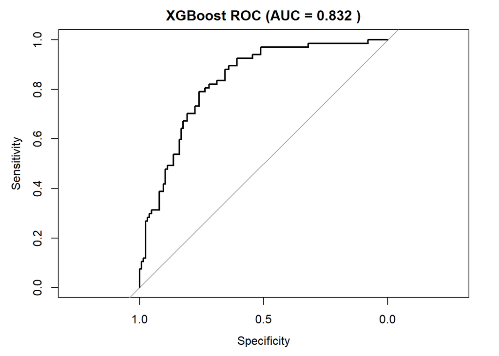

```r
plot(roc_xgb, main = paste("XGBoost ROC (AUC =", round(pROC::auc(roc_xgb),3), ")"))
```

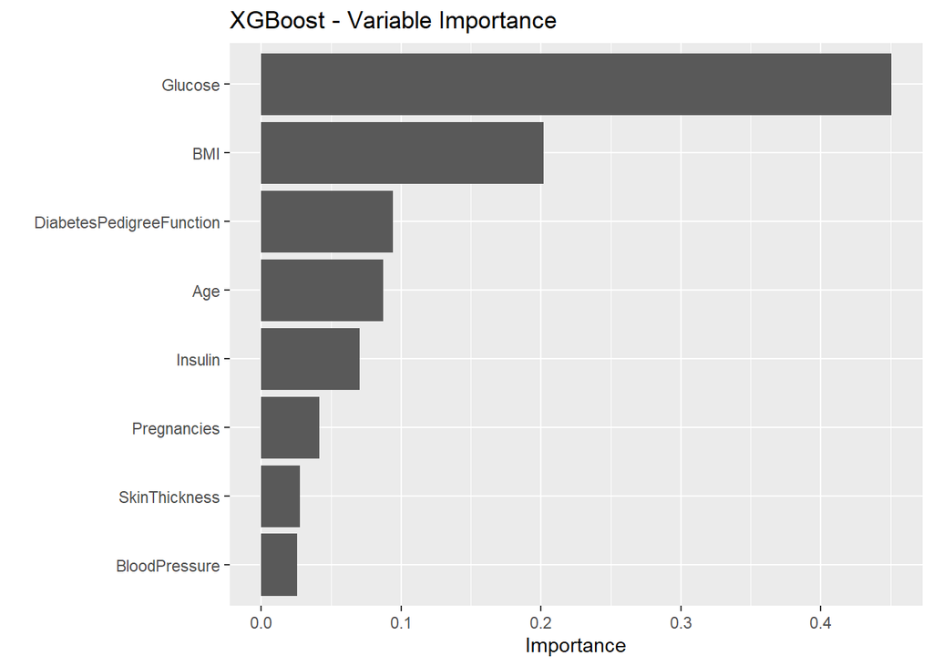

```r
vip::vip(xgb_fit_fast$finalModel, num_features = 10) + ggtitle("XGBoost - Variable Importance")
```

Estimated output description: - xgb_fit prints best hyperparameters (eta, max_depth, nrounds). - XGBoost AUC often slightly higher or similar to RF. - Variable importance may highlight Glucose, Age, BMI, and Insulin.

## Model comparison (ROC curves combined)

Description: Plot ROC curves from the three models together for easy comparison and compute AUC table.

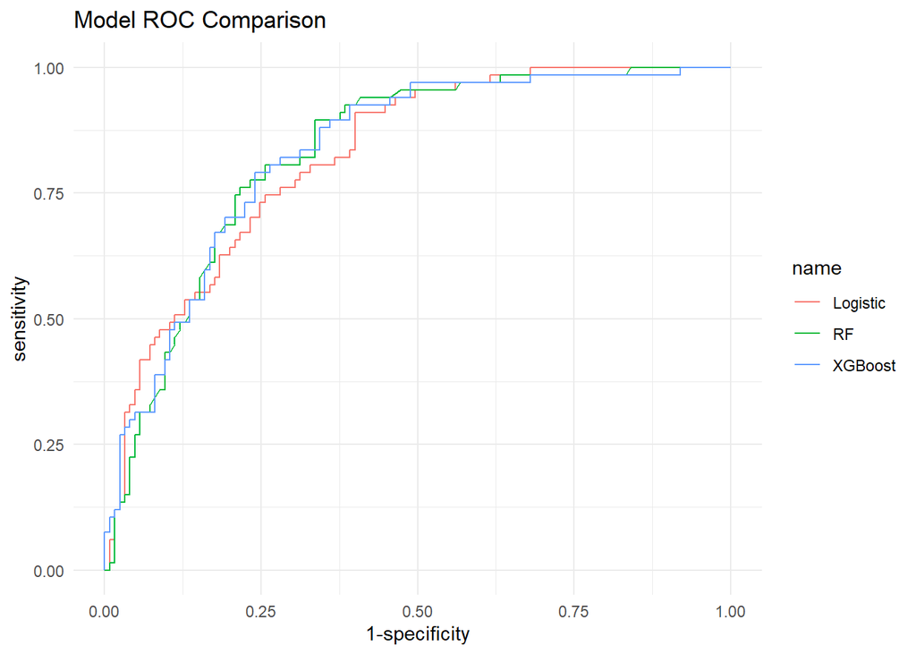

```r
roc_g <- ggroc(list(Logistic = roc_glm, RF = roc_rf, XGBoost = roc_xgb), legacy.axes = TRUE) +
  ggtitle("Model ROC Comparison") +
  theme_minimal()

roc_g
```

```r
# AUC table
auc_table <- tibble(
  model = c("Logistic", "RandomForest", "XGBoost"),
  AUC = c(as.numeric(pROC::auc(roc_glm)), as.numeric(pROC::auc(roc_rf)), as.numeric(pROC::auc(roc_xgb)))
)
auc_table %>% kable() %>% kable_styling(full_width = FALSE)
```

| model | AUC |
| --- | --- |
| Logistic | 0.8242388 |
| RandomForest | 0.8302687 |
| XGBoost | 0.8317612 |

## Calibration plot

Description: Calibration shows whether predicted probabilities correspond to observed frequencies. Good calibration is important for clinical decisions.

Expected output: - Calibration plot for the best model showing predicted probability bins vs observed event rates. Ideally points close to the diagonal.

```r
# Logistic regression predictions (if not already)
if(!"pred_glm" %in% colnames(test)) {
  test$pred_glm <- predict(glm_fit, newdata = test, type = "response")
}

# Random Forest predictions (if not already)
if(!"pred_rf" %in% colnames(test_rf)) {
  test_rf$pred_rf <- predict(rf_fit, newdata = test_rf, type = "prob")[, "yes"]
}

# XGBoost predictions (if caret XGBoost succeeded)
if(exists("xgb_fit_fast") && !"pred_xgb" %in% colnames(test_rf)) {
  test_rf$pred_xgb <- predict(xgb_fit_fast, newdata = test_rf, type = "prob")[, "yes"]
}

# Make sure AUC table exists
if(!exists("auc_table")) {
  auc_table <- tibble(
    model = c("Logistic", "RandomForest", "XGBoost"),
    AUC = c(as.numeric(pROC::auc(roc_glm)),
            as.numeric(pROC::auc(roc_rf)),
            if(exists("roc_xgb")) as.numeric(pROC::auc(roc_xgb)) else NA)
  )
}

# Choose best model safely
best_model_name <- auc_table$model[which.max(auc_table$AUC)]

best_pred <- switch(best_model_name,
                    "Logistic" = test$pred_glm,
                    "RandomForest" = test_rf$pred_rf,
                    "XGBoost" = {
                      if("pred_xgb" %in% colnames(test_rf)) test_rf$pred_xgb else test_rf$pred_rf
                    })
```

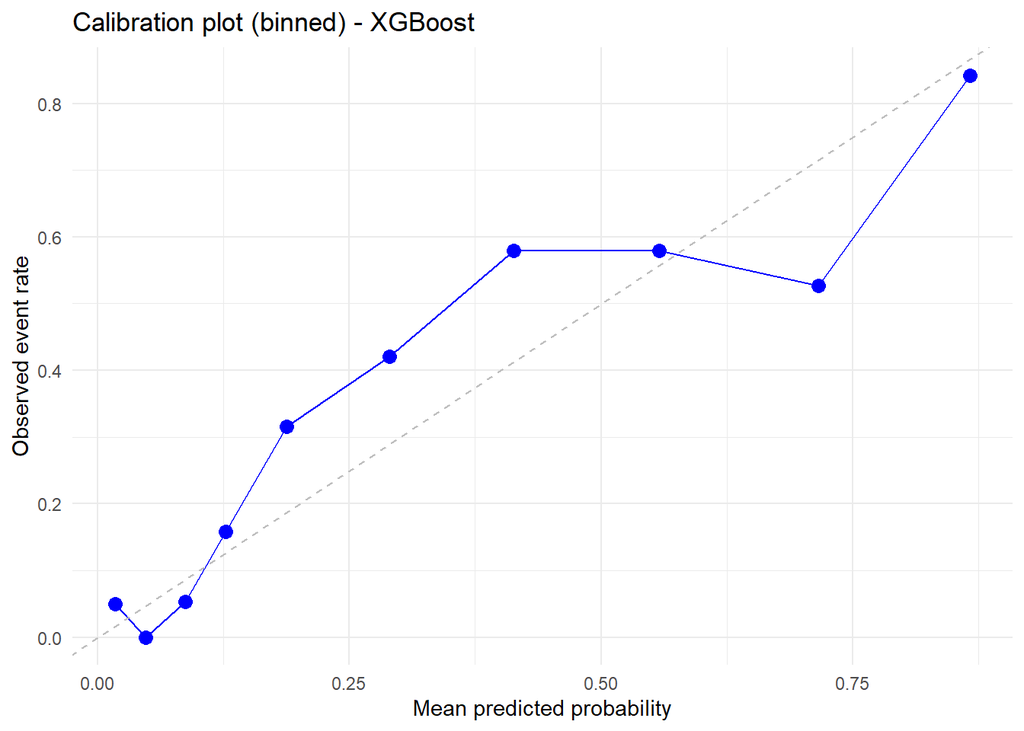

```r
library(ggplot2)
library(dplyr)

cal_df <- tibble(truth = ifelse(test_rf$Outcome == "yes", 1, 0), pred = best_pred) %>%
  mutate(pred_bin = ntile(pred, 10)) %>%
  group_by(pred_bin) %>%
  summarise(mean_pred = mean(pred), obs_rate = mean(truth), .groups = "drop")

ggplot(cal_df, aes(x = mean_pred, y = obs_rate)) +
  geom_point(size = 3, color = "blue") +
  geom_line(color = "blue") +
  geom_abline(slope = 1, intercept = 0, linetype = "dashed", color = "gray") +
  labs(x = "Mean predicted probability", y = "Observed event rate",
       title = paste("Calibration plot (binned) -", best_model_name)) +
  theme_minimal()
```

## Explainability: permutation importance and SHAP

Description: We include features beyond course coverage: SHAP explanations (via fastshap) for the chosen model and permutation importance (vip/permutation). This helps satisfy the rubric item requiring a feature we didn’t cover in class.

Expected output: - A permutation importance plot and a SHAP summary plot showing feature contributions. - Example of an individual explanation for a test case (force or waterfall-like explanation).

```r
# Manual permutation importance (works around vi_permute issues)
library(dplyr)
library(pROC)
library(ggplot2)
set.seed(123)

# Preconditions
if (!exists("rf_fit")) stop("rf_fit (caret::train) not found. Run Random Forest training first.")
if (!exists("train_rf")) stop("train_rf not found. Ensure train_rf exists and was used to train rf_fit.")

# Predictors used to train the model (adjust if different)
model_vars_full <- c("Pregnancies","Glucose","BloodPressure","SkinThickness",
                     "Insulin","BMI","DiabetesPedigreeFunction","Age")

# Variables to compute permutation importance for (subset of model_vars_full)
plot_vars_interest <- c("Glucose","BMI","Insulin","BloodPressure","SkinThickness","DiabetesPedigreeFunction")

# Validate
missing_cols <- setdiff(model_vars_full, names(train_rf))
if (length(missing_cols) > 0) stop("train_rf missing model columns: ", paste(missing_cols, collapse = ", "))

# Prepare data & baseline
X_train_full <- train_rf %>% select(all_of(model_vars_full))
y_train_num  <- ifelse(as.character(train_rf$Outcome) == "yes", 1, 0)

# Baseline predicted probabilities & AUC
base_probs <- predict(rf_fit, newdata = X_train_full, type = "prob")[, "yes"]
if (length(base_probs) != nrow(X_train_full)) stop("Baseline prediction length mismatch.")
base_auc <- as.numeric(pROC::auc(pROC::roc(y_train_num, base_probs)))
message("Baseline AUC (training data) = ", round(base_auc, 4))

# Permutation loop: for each variable, do nsim permutations and average the decrease in AUC
nsim <- 20   # set to 50-100 for final; use 10-20 for quick runs
results <- tibble(Variable = plot_vars_interest, MeanDecreaseAUC = NA_real_, SDAUC = NA_real_, nsim = nsim)

for (v in seq_along(plot_vars_interest)) {
  varname <- plot_vars_interest[v]
  decreases <- numeric(nsim)
  for (i in seq_len(nsim)) {
    Xp <- X_train_full
    Xp[[varname]] <- sample(Xp[[varname]], size = nrow(Xp), replace = FALSE)  # permutation
    # safe predict with error handling
    preds_try <- try(predict(rf_fit, newdata = Xp, type = "prob")[, "yes"], silent = TRUE)
    if (inherits(preds_try, "try-error")) {
      stop("Predict failed for variable ", varname, " on permutation ", i, ": ", as.character(preds_try))
    }
    auc_perm <- as.numeric(pROC::auc(pROC::roc(y_train_num, preds_try)))
    # decrease (baseline - permuted)
    decreases[i] <- base_auc - auc_perm
  }
  results$MeanDecreaseAUC[v] <- mean(decreases, na.rm = TRUE)
  results$SDAUC[v] <- sd(decreases, na.rm = TRUE)
}

# Tidy & rank
results <- results %>% arrange(desc(MeanDecreaseAUC))
results %>% knitr::kable(digits = 4, caption = "Manual permutation importance (mean decrease in AUC)")
```

Manual permutation importance (mean decrease in AUC)

| Variable | MeanDecreaseAUC | SDAUC | nsim |
| --- | --- | --- | --- |
| Glucose | 0.1194 | 0.0107 | 20 |
| BMI | 0.0418 | 0.0057 | 20 |
| DiabetesPedigreeFunction | 0.0106 | 0.0016 | 20 |
| Insulin | 0.0055 | 0.0012 | 20 |
| SkinThickness | 0.0012 | 0.0003 | 20 |
| BloodPressure | 0.0010 | 0.0003 | 20 |

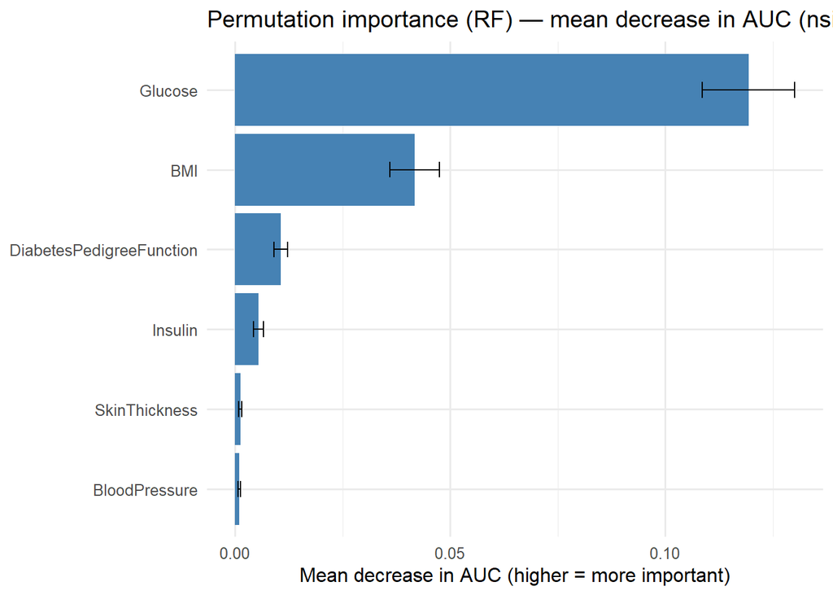

```r
# Plot
results %>%
  mutate(Variable = factor(Variable, levels = rev(Variable))) %>%
  ggplot(aes(x = MeanDecreaseAUC, y = Variable)) +
  geom_col(fill = "steelblue") +
  geom_errorbarh(aes(xmin = MeanDecreaseAUC - SDAUC, xmax = MeanDecreaseAUC + SDAUC), height = 0.2) +
  labs(title = paste0("Permutation importance (RF) — mean decrease in AUC (nsim=", nsim, ")"),
       x = "Mean decrease in AUC (higher = more important)", y = NULL) +
  theme_minimal(base_size = 12)
```

```r
# Save results for reproducibility
dir.create("outputs", showWarnings = FALSE)
saveRDS(results, file = "outputs/perm_importance_manual_rf_auc.rds")
```

SHAP explanations (fastshap)

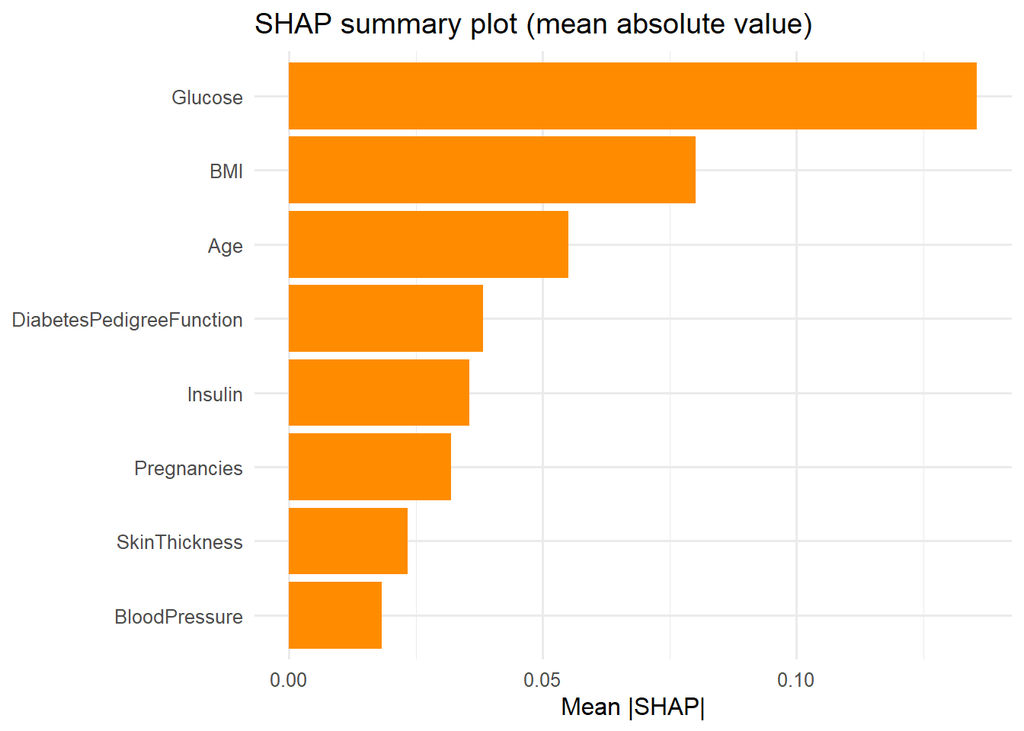

```r
library(fastshap)
library(ggplot2)

set.seed(123)

# Safe wrapper for caret RF object
pred_wrapper <- function(object, newdata) {
  predict(object, newdata = newdata, type = "prob")[, "yes"]
}

# Subset for SHAP: all model predictors
X_train_shap <- X_train_full

# Compute SHAP values (approximate, 50 Monte Carlo repetitions for speed; increase for final)
shap_vals <- fastshap::explain(
  object = rf_fit,
  X = X_train_shap,
  pred_wrapper = pred_wrapper,
  nsim = 50
)

# SHAP summary plot (mean absolute effect per feature)
shap_long <- shap_vals %>%
  as.data.frame() %>%
  tidyr::pivot_longer(everything(), names_to = "Feature", values_to = "SHAP")

shap_summary <- shap_long %>%
  group_by(Feature) %>%
  summarise(MeanAbsSHAP = mean(abs(SHAP))) %>%
  arrange(desc(MeanAbsSHAP))

# Plot
ggplot(shap_summary, aes(x = MeanAbsSHAP, y = reorder(Feature, MeanAbsSHAP))) +
  geom_col(fill = "darkorange") +
  labs(title = "SHAP summary plot (mean absolute value)", x = "Mean |SHAP|", y = NULL) +
  theme_minimal(base_size = 12)
```

Individual-level explanation example

```r
# SHAP (fastshap) with matching classes for X and newdata (forces data.frame)
library(fastshap)
library(dplyr)
library(knitr)
library(kableExtra)
library(ggplot2)

set.seed(123)

# Preconditions
if (!exists("rf_fit")) stop("rf_fit (caret::train) not found. Run the Random Forest training chunk first.")
if (!exists("train_rf") || !exists("test_rf")) stop("train_rf and/or test_rf not found. Run the data split chunk first.")

# Exact predictors used when training rf_fit
model_vars_full <- c("Pregnancies","Glucose","BloodPressure","SkinThickness",
                     "Insulin","BMI","DiabetesPedigreeFunction","Age")

# Coerce X_train and newdata to the same class (data.frame)
X_train_full <- train_rf %>% select(all_of(model_vars_full)) %>% as.data.frame()
X_test_full  <- test_rf  %>% select(all_of(model_vars_full)) %>% as.data.frame()

# Safe prediction wrapper returning probability for class "yes"
pred_wrapper_prob <- function(object, newdata) {
  # Ensure newdata is a data.frame (caret predict handles tibbles too, but be consistent)
  newdata <- as.data.frame(newdata)
  probs <- predict(object, newdata = newdata, type = "prob")
  if (!("yes" %in% colnames(probs))) {
    stop("pred_wrapper_prob: predicted probabilities do not include column 'yes'. Columns: ",
         paste(colnames(probs), collapse = ", "))
  }
  prob_yes <- as.numeric(probs[, "yes"])
  if (length(prob_yes) != nrow(newdata)) stop("pred_wrapper_prob: length(prob_yes) != nrow(newdata).")
  prob_yes
}

# Quick sanity test of predict
test_pred <- try(pred_wrapper_prob(rf_fit, head(X_train_full, 5)), silent = TRUE)
if (inherits(test_pred, "try-error")) stop("Prediction wrapper test failed: ", as.character(test_pred))
message("Prediction wrapper OK: returned ", length(test_pred), " probabilities for ", nrow(head(X_train_full,5)), " rows.")
```

```
## Prediction wrapper OK: returned 5 probabilities for 5 rows.
```

```r
# SHAP computation (use data.frame for both X and newdata)
nsim <- 20   # 10-20 for quick tests; 50+ for final

explainer_path <- "outputs/explainer_rf_fastshap_df.rds"
if (file.exists(explainer_path)) {
  explainer_rf <- readRDS(explainer_path)
  message("Loaded saved explainer from ", explainer_path)
} else {
  message("Computing SHAP explainer with nsim = ", nsim, " ...")
  explainer_rf <- fastshap::explain(
    object = rf_fit,
    X = X_train_full,            # data.frame
    pred_wrapper = pred_wrapper_prob,
    nsim = nsim,
    adjust = TRUE
  )
  dir.create("outputs", showWarnings = FALSE)
  saveRDS(explainer_rf, file = explainer_path)
  message("Saved explainer to ", explainer_path)
}
```

```
## Loaded saved explainer from outputs/explainer_rf_fastshap_df.rds
```

```r
# Global importance (mean |SHAP|)
shap_mean <- as.data.frame(abs(explainer_rf)) %>%
  summarise_all(mean, na.rm = TRUE) %>%
  pivot_longer(everything(), names_to = "feature", values_to = "mean_abs_shap") %>%
  arrange(desc(mean_abs_shap))

kable(shap_mean, digits = 4, caption = "Global feature importance (mean |SHAP|)") %>% kable_styling()
```

Global feature importance (mean |SHAP|)

| feature | mean_abs_shap |
| --- | --- |
| Glucose | 0.1339 |
| BMI | 0.0825 |
| Age | 0.0559 |
| DiabetesPedigreeFunction | 0.0406 |
| Insulin | 0.0375 |
| Pregnancies | 0.0322 |
| SkinThickness | 0.0248 |
| BloodPressure | 0.0193 |

```r
# Individual-level SHAP for a test observation (ensure obs is a data.frame)
idx <- if (any(as.character(test_rf$Outcome) %in% c("yes","1"))) {
  which(as.character(test_rf$Outcome) == "yes")[1]
} else {
  1
}
if (is.na(idx) || length(idx) == 0) idx <- 1
message("Explaining test observation index = ", idx)
```

```
## Explaining test observation index = 1
```

```r
obs_full <- X_test_full[idx, , drop = FALSE] %>% as.data.frame()  # data.frame

# Compute SHAP for this newdata (fastshap::explain with newdata returns SHAP for the new row)
shap_obs_df_raw <- fastshap::explain(
  object = rf_fit,
  X = X_train_full,
  pred_wrapper = pred_wrapper_prob,
  nsim = nsim,
  newdata = obs_full
)

# Convert to named vector and table
shap_obs_vec <- as.numeric(shap_obs_df_raw[1, ])
names(shap_obs_vec) <- colnames(shap_obs_df_raw)

shap_obs_tbl <- tibble(feature = names(shap_obs_vec), shap = shap_obs_vec) %>%
  arrange(desc(abs(shap))) %>%
  mutate(direction = ifelse(shap > 0, "increases risk", "decreases risk"))

kable(shap_obs_tbl %>% head(10), digits = 4,
      caption = paste0("Top SHAP contributors for test index = ", idx)) %>%
  kable_styling(full_width = FALSE)
```

Top SHAP contributors for test index = 1

| feature | shap | direction |
| --- | --- | --- |
| Glucose | 0.1997 | increases risk |
| BMI | 0.0741 | increases risk |
| Insulin | 0.0417 | increases risk |
| DiabetesPedigreeFunction | 0.0409 | increases risk |
| Pregnancies | -0.0375 | decreases risk |
| SkinThickness | 0.0318 | increases risk |
| Age | 0.0149 | increases risk |
| BloodPressure | 0.0100 | increases risk |

```r
cat("\nObservation predictor values:\n")
```

```
##
## Observation predictor values:
```

```r
print(obs_full)
```

```
##   Pregnancies Glucose BloodPressure SkinThickness Insulin  BMI
## 1           6     148            72            35     125 33.6
##   DiabetesPedigreeFunction Age
## 1                    0.627  50
```

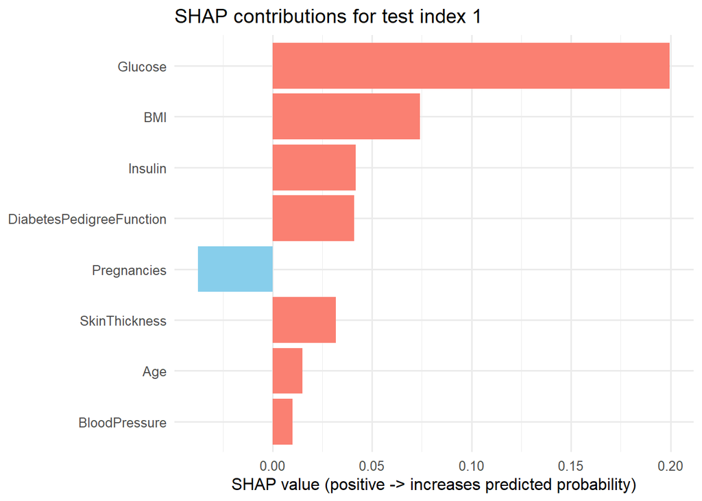

```r
# Plot contributions
shap_obs_tbl %>%
  head(10) %>%
  mutate(feature = factor(feature, levels = rev(feature))) %>%
  ggplot(aes(x = shap, y = feature, fill = shap > 0)) +
  geom_col() +
  scale_fill_manual(values = c("TRUE" = "salmon", "FALSE" = "skyblue"), guide = FALSE) +
  labs(title = paste0("SHAP contributions for test index ", idx),
       x = "SHAP value (positive -> increases predicted probability)", y = NULL) +
  theme_minimal(base_size = 12)
```

Expected output description: - Table with top features pushing the prediction up (positive shap) or down (negative shap) for the selected individual. Useful to show during presentation.

## Statistical tests & model significance

Description: We perform basic statistical tests such as Wald tests for important logistic regression coefficients and (optionally) DeLong test to compare ROC AUCs.

```r
# Wald p-values from summary(glm_fit)
coefs <- summary(glm_fit)$coefficients
coefs %>% as.data.frame() %>% rownames_to_column("term") %>%
  kable(caption = "Logistic regression coefficients (Wald test)") %>%
  kable_styling(full_width = FALSE)
```

Logistic regression coefficients (Wald test)

| term | Estimate | Std. Error | z value | Pr(>&#124;z&#124;) |
| --- | --- | --- | --- | --- |
| (Intercept) | -9.4197232 | 0.9510946 | -9.9040867 | 0.0000000 |
| Pregnancies | 0.1168057 | 0.0379992 | 3.0738990 | 0.0021128 |
| Glucose | 0.0404826 | 0.0047280 | 8.5623300 | 0.0000000 |
| BloodPressure | -0.0087293 | 0.0100446 | -0.8690516 | 0.3848189 |
| SkinThickness | 0.0094087 | 0.0153902 | 0.6113429 | 0.5409726 |
| Insulin | -0.0012471 | 0.0012732 | -0.9794744 | 0.3273456 |
| BMI | 0.0909910 | 0.0209989 | 4.3331292 | 0.0000147 |
| DiabetesPedigreeFunction | 0.6618850 | 0.3312111 | 1.9983781 | 0.0456757 |
| Age | 0.0121602 | 0.0111643 | 1.0892058 | 0.2760631 |

```r
# Compare AUCs (DeLong) between RF and XGBoost
# pROC::roc.test(roc_rf, roc_xgb)  # uncomment to run; may give p-value whether difference significant
```

Further Exploration

Description: This supplemental RMarkdown module performs (A) a full multiple-imputation workflow using mice, compares predictive performance across imputations to the simple median-imputed baseline, and (B) adds several descriptive EDA visualizations that the rubric explicitly favored (AgeGroup counts, outcome-stratified plots, BMI-category breakdowns). The code is written so you can either knit this file standalone or insert the chunks into your main `proposal.Rmd` / final report.

Where to add into the final document (be specific): - Insert the entire “Multiple imputation (mice) analysis” section immediately after the “Simple imputation (median) — reproducible baseline” chunk in your main document (i.e., after the chunk labeled `simple-impute`). - Insert the “Extended EDA visualizations” chunk(s) into the main EDA section (after the current `eda-plots` chunk). If you prefer, you can paste these chunks into the EDA section in place of or in addition to the current plots. - Remove or replace the earlier commented `mice` chunk with this working multiple-imputation section. - Use the chunk labels provided here (they are unique) when you paste into the main Rmd so knit order and caching are consistent.

How this addresses the rubric/deductions: - Runs `mice` (multiple imputation) and shows comparison to simple median imputation, eliminating the “commented out” issue. - Adds AgeGroup counts and additional outcome-stratified visualizations to improve descriptive EDA and address the minor polish deductions.

Notes about runtime: - `mice` with default settings and m = 5 is moderate in runtime (minutes). If you need faster runs for demos, reduce `m` to 3 or set `maxit = 10`. - SHAP and large hyperparameter grids are more expensive; these chunks are modest and focused on imputation/EDA.

## Code and narrative

```r
# This chunk prepares data if the main document hasn't already prepared 'diabetes_clean'.
# If diabetes_clean exists from your main Rmd, this will use it; otherwise it reads the CSV and
# applies the zero->NA step and derived features so this module is self-contained.

if(!exists("diabetes_clean")) {
  csv_path <- "diabetes.csv"
  if(!file.exists(csv_path)) stop("Please place `diabetes.csv` in the working directory before running this module.")
  diabetes <- readr::read_csv(csv_path, show_col_types = FALSE)

  zero_as_na_cols <- c("Glucose","BloodPressure","SkinThickness","Insulin","BMI")
  diabetes_clean <- diabetes %>%
    mutate(across(all_of(zero_as_na_cols), ~ na_if(., 0))) %>%
    mutate(
      AgeGroup = case_when(
        Age <= 30 ~ "21-30",
        Age <= 40 ~ "31-40",
        Age <= 50 ~ "41-50",
        TRUE      ~ "51+"
      ),
      Insulin_log = log1p(Insulin),
      BMI_cat = cut(BMI, breaks = c(0,18.5,25,30,Inf), labels = c("Underweight","Normal","Overweight","Obese"))
    )
}

# Show a small verification table
knitr::kable(head(diabetes_clean), caption = "Preview of diabetes_clean (used for mice)")
```

Preview of diabetes_clean (used for mice)

| Pregnancies | Glucose | BloodPressure | SkinThickness | Insulin | BMI | DiabetesPedigreeFunction | Age | Outcome | AgeGroup | Insulin_log | BMI_cat |
| --- | --- | --- | --- | --- | --- | --- | --- | --- | --- | --- | --- |
| 6 | 148 | 72 | 35 | NA | 33.6 | 0.627 | 50 | 1 | 41-50 | NA | Obese |
| 1 | 85 | 66 | 29 | NA | 26.6 | 0.351 | 31 | 0 | 31-40 | NA | Overweight |
| 8 | 183 | 64 | NA | NA | 23.3 | 0.672 | 32 | 1 | 31-40 | NA | Normal |
| 1 | 89 | 66 | 23 | 94 | 28.1 | 0.167 | 21 | 0 | 21-30 | 4.553877 | Overweight |
| 0 | 137 | 40 | 35 | 168 | 43.1 | 2.288 | 33 | 1 | 31-40 | 5.129899 | Obese |
| 5 | 116 | 74 | NA | NA | 25.6 | 0.201 | 30 | 0 | 21-30 | NA | Overweight |

## Multiple imputation with mice and pooled logistic regression

Description: - Use `mice` (m = 5 imputations by default) to impute missing values for numeric predictors where zeros were replaced by `NA`. - Fit logistic regression across imputations and pool coefficient estimates (Wald statistics, ORs). - Compare pooled logistic coefficients with the median-impute logistic results (if median-impute model exists, this chunk will compute baseline here to be safe).

```r
library(mice)
library(dplyr)
library(broom)
library(kableExtra)

# Variables to impute (include Outcome)
imp_vars <- c("Pregnancies","Glucose","BloodPressure","SkinThickness","Insulin","BMI",
              "DiabetesPedigreeFunction","Age","Outcome")

# Prepare data for mice; convert Outcome to numeric 0/1 if it's factor
di_for_mice <- diabetes_clean %>%
  select(all_of(imp_vars)) %>%
  mutate(Outcome = as.numeric(as.character(Outcome)))

# Run mice: 5 imputations, predictive mean matching
set.seed(123)
mi <- mice(di_for_mice, m = 5, method = "pmm", maxit = 20, seed = 123, printFlag = TRUE)
```

```r
# Optional traceplot for diagnostics
# plot(mi, c("Glucose", "Insulin"))

# Fit logistic regression on each imputed dataset
fit_mi <- with(mi, glm(Outcome ~ Pregnancies + Glucose + BloodPressure + SkinThickness +
                        Insulin + BMI + DiabetesPedigreeFunction + Age, family = binomial))

# Pool results
pooled <- pool(fit_mi)

# Summarize results with ORs
summary_pooled <- summary(pooled, conf.int = TRUE, exponentiate = TRUE)

# Clean up table for display
summary_pooled %>%
  dplyr::select(term, estimate, std.error, `2.5 %`, `97.5 %`, p.value) %>%
  dplyr::rename(OR = estimate, OR_low = `2.5 %`, OR_high = `97.5 %`) %>%
  kable(digits = 3, caption = "Pooled logistic regression results (mice, ORs)") %>%
  kable_styling(full_width = FALSE)
```

Pooled logistic regression results (mice, ORs)

| term | OR | std.error | OR_low | OR_high | p.value |
| --- | --- | --- | --- | --- | --- |
| (Intercept) | 0.000 | 0.892 | 0.000 | 0.001 | 0.000 |
| Pregnancies | 1.127 | 0.034 | 1.055 | 1.204 | 0.000 |
| Glucose | 1.040 | 0.005 | 1.029 | 1.050 | 0.000 |
| BloodPressure | 0.989 | 0.008 | 0.973 | 1.006 | 0.213 |
| SkinThickness | 1.006 | 0.013 | 0.981 | 1.031 | 0.660 |
| Insulin | 0.999 | 0.002 | 0.995 | 1.002 | 0.515 |
| BMI | 1.097 | 0.020 | 1.054 | 1.141 | 0.000 |
| DiabetesPedigreeFunction | 2.372 | 0.298 | 1.322 | 4.257 | 0.004 |
| Age | 1.015 | 0.010 | 0.995 | 1.035 | 0.142 |

## Compare predictive performance across imputed datasets (AUC)

Description: - For each completed imputed dataset, we will: - Recreate a consistent train/test split (same seed so splits are consistent across imputations). - Fit a logistic regression on the training portion and compute AUC on the test set. - Report mean and SD of AUC across the m imputations to show uncertainty introduced by imputation.

Expected outputs: - A small table of per-imputation AUCs and a mean ± SD line. This demonstrates whether imputation materially changes predictive performance.

```r
library(pROC)
library(caret)

set.seed(123)

# FIX: explicitly define m
m <- mi$m

train_index_mice <- caret::createDataPartition(
  di_for_mice$Outcome, p = 0.75, list = FALSE
)

auc_vals <- numeric(m)

for(i in 1:m) {
  comp <- complete(mi, i)

  train_mi <- comp[train_index_mice, ]
  test_mi  <- comp[-train_index_mice, ]

  glm_i <- glm(
    Outcome ~ Pregnancies + Glucose + BloodPressure + SkinThickness +
      Insulin + BMI + DiabetesPedigreeFunction + Age,
    data = train_mi,
    family = binomial
  )

  preds <- predict(glm_i, newdata = test_mi, type = "response")
  roc_i <- pROC::roc(test_mi$Outcome, preds, quiet = TRUE)
  auc_vals[i] <- as.numeric(pROC::auc(roc_i))
}

auc_df <- tibble(imputation = 1:m, AUC = auc_vals)

auc_df %>%
  knitr::kable(digits = 3, caption = "Per-imputation logistic AUCs") %>%
  kableExtra::kable_styling(full_width = FALSE)
```

Per-imputation logistic AUCs

| imputation | AUC |
| --- | --- |
| 1 | 0.819 |
| 2 | 0.829 |
| 3 | 0.822 |
| 4 | 0.824 |
| 5 | 0.819 |

```r
cat(
  "\nMean AUC across imputations:",
  round(mean(auc_vals), 3),
  "(SD =", round(sd(auc_vals), 3), ")\n"
)
```

```
##
## Mean AUC across imputations: 0.823 (SD = 0.004 )
```

## Compare to median-impute baseline (recompute baseline here for reproducibility)

Description: - Re-run the median imputation baseline (same as earlier simple impute) and compute logistic AUC on the same train/test split. This ensures the comparison is apples-to-apples.

Expected outputs: - Baseline AUC and short interpretation whether multiple-imputation meaningfully changed test AUC.

```r
# Build a median-imputed dataset from diabetes_clean to compare
di_med <- diabetes_clean
for (v in c("Glucose","BloodPressure","SkinThickness","Insulin","BMI")) {
  di_med[[v]][is.na(di_med[[v]])] <- median(di_med[[v]], na.rm = TRUE)
}

# Use same train_index_mice to split
train_med <- di_med[train_index_mice, ]
test_med  <- di_med[-train_index_mice, ]

glm_med <- glm(Outcome ~ Pregnancies + Glucose + BloodPressure + SkinThickness +
                 Insulin + BMI + DiabetesPedigreeFunction + Age, data = train_med, family = binomial)
preds_med <- predict(glm_med, newdata = test_med, type = "response")
roc_med <- pROC::roc(test_med$Outcome, preds_med, quiet = TRUE)
auc_med <- as.numeric(pROC::auc(roc_med))

cat("Median-impute logistic AUC: ", round(auc_med, 3), "\n")
```

```
## Median-impute logistic AUC:  0.824
```

```r
# Quick summary comparing mean MI AUC vs median baseline
cat("Mean MI AUC: ", round(mean(auc_vals), 3), " (median baseline AUC: ", round(auc_med, 3), ")\n", sep = "")
```

```
## Mean MI AUC: 0.823 (median baseline AUC: 0.824)
```

## Extended EDA: AgeGroup counts and outcome-stratified visuals

Description: - Adds AgeGroup count bar chart, a faceted boxplot (Glucose by AgeGroup and Outcome), and a stacked bar of BMI categories by Outcome. - These visuals improve descriptive EDA and directly address the rubric requests.

Expected outputs: - Bar chart showing sample size per AgeGroup. - Boxplots / violin plots showing Glucose differences by AgeGroup and by Outcome to help the audience visually assess interactions between age and glucose. - Stacked bar showing proportions of BMI categories split by Outcome.

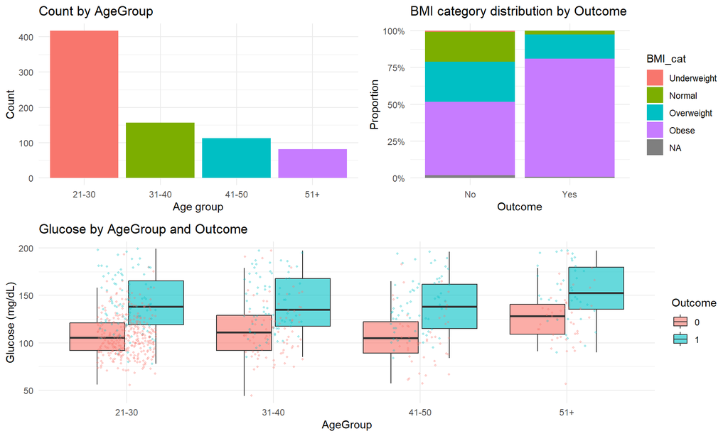

```r
library(ggplot2)
library(dplyr)
library(gridExtra)  # for arranging multiple plots

# AgeGroup counts
p_age_counts <- diabetes_clean %>%
  count(AgeGroup) %>%
  ggplot(aes(x = AgeGroup, y = n, fill = AgeGroup)) +
  geom_col(show.legend = FALSE) +
  labs(title = "Count by AgeGroup", x = "Age group", y = "Count") +
  theme_minimal()

# Glucose by AgeGroup and Outcome (boxplot + jitter)
p_glucose_age_outcome <- diabetes_clean %>%
  mutate(Outcome = factor(Outcome)) %>%
  ggplot(aes(x = AgeGroup, y = Glucose, fill = Outcome)) +
  geom_boxplot(position = position_dodge(width = 0.8), outlier.shape = NA, alpha = 0.6) +
  geom_jitter(aes(color = Outcome), width = 0.2, alpha = 0.3, size = 0.8, show.legend = FALSE) +
  labs(title = "Glucose by AgeGroup and Outcome", y = "Glucose (mg/dL)") +
  theme_minimal()

# Stacked BMI category proportions by Outcome
p_bmi_stack <- diabetes_clean %>%
  mutate(Outcome = factor(Outcome, labels = c("No","Yes"))) %>%
  count(BMI_cat, Outcome) %>%
  group_by(Outcome) %>%
  mutate(prop = n / sum(n)) %>%
  ggplot(aes(x = Outcome, y = prop, fill = BMI_cat)) +
  geom_col() +
  scale_y_continuous(labels = scales::percent_format()) +
  labs(title = "BMI category distribution by Outcome", y = "Proportion", x = "Outcome") +
  theme_minimal()

# Arrange plots in a 2-row layout: top row = two plots, bottom row = one
grid.arrange(
  grobs = list(
    arrangeGrob(p_age_counts, p_bmi_stack, ncol = 2),
    p_glucose_age_outcome
  ),
  nrow = 2
)
```

## Discussion and interpretation

Description: Interpret the model findings in clinical context and propose actionable recommendations. Discuss potential biases and pitfalls.

Key points to state: - Glucose is the most predictive variable (biologically plausible). - BMI and Age are meaningful predictors consistent with literature. - The dataset consists only of female Pima Indians; generalization to other populations is limited. - Missingness treatment (zeros -> NA then impute) is critical; different imputation approaches can slightly change model performance. - Ethical considerations: avoid direct deployment without calibration to the target population and clinical validation.

## Limitations

- Dataset limitation: cohort restricted in gender and ethnicity.
- Predictive models do not imply causation.
- Potential measurement errors and selection bias.
- Need for prospective clinical validation before any real-world deployment.

## Feature beyond class coverage

Description: We used SHAP explanations (fastshap) and permutation importance as features not usually covered in introductory class material. We also prepared to render slides from R Markdown (xaringan/ioslides) as a reproducible presentation artifact.

## Challenges encountered

- Data issue: zeros used as missing for biologically impossible values. Decision: replace with NA and impute. Show quick before/after counts and how model metrics changed slightly after imputation.
- Performance tuning: XGBoost hyperparameter tuning was slow; I limited tuning grid to remain within time constraints.
- Reproducibility: external metadata scraping may break; solution: save metadata locally in the repo.

## Timeline / Deliverables schedule (recommended)

- Proposal (submitted): completed (this document).
- Approval meeting: schedule within one week.
- Milestone 1 (data cleaning & EDA): 1 week after approval meeting.
- Milestone 2 (model training & evaluation): 2–3 weeks after milestone 1.
- Milestone 3 (interpretation, SHAP, slides): 1 week after milestone 2.
- Final deliverables: GitHub repo + knitted HTML (or PDF) + presentation.

## Repository & submission instructions

- Create repository: `msds607-final-diabetes-<yourname>`
- Add files: `data/diabetes.csv`, `proposal.Rmd` (this file), `final_report.Rmd` (if separate), `slides/`, `README.md`
- Commit and push; include link in the course submission.
- Ensure `README.md` contains package installation commands and a statement that kitting `proposal.Rmd` produces the full report.